# Ford GoBike System Data

## by/ Ahmad Mostafa

> **2017-fordgobike-tripdata**, Each trip is anonymized and includes:
> - Trip Duration (seconds)
> - Start Time and Date
> - End Time and Date
> - Start Station ID
> - Start Station Name
> - Start Station Latitude
> - Start Station Longitude
> - End Station ID
> - End Station Name
> - End Station Latitude
> - End Station Longitude
> - Bike ID
> - User Type (Subscriber or Customer – “Subscriber” = Member or “Customer” = Casual)

```python
# import all packages and set plots to be embedded inline
import numpy as np
import pandas as pd
import matplotlib.pyplot as plt
import seaborn as sb

%matplotlib inline
```

```python
df= pd.read_csv('2017-fordgobike-tripdata.csv')
df.head()
```

|  | duration_sec | start_time | end_time | start_station_id | start_station_name | start_station_latitude | start_station_longitude | end_station_id | end_station_name | end_station_latitude | end_station_longitude | bike_id | user_type |
| --- | --- | --- | --- | --- | --- | --- | --- | --- | --- | --- | --- | --- | --- |
| 0 | 80110 | 2017-12-31 16:57:39.6540 | 2018-01-01 15:12:50.2450 | 74 | Laguna St at Hayes St | 37.776435 | -122.426244 | 43 | San Francisco Public Library (Grove St at Hyde... | 37.778768 | -122.415929 | 96 | Customer |
| 1 | 78800 | 2017-12-31 15:56:34.8420 | 2018-01-01 13:49:55.6170 | 284 | Yerba Buena Center for the Arts (Howard St at ... | 37.784872 | -122.400876 | 96 | Dolores St at 15th St | 37.766210 | -122.426614 | 88 | Customer |
| 2 | 45768 | 2017-12-31 22:45:48.4110 | 2018-01-01 11:28:36.8830 | 245 | Downtown Berkeley BART | 37.870348 | -122.267764 | 245 | Downtown Berkeley BART | 37.870348 | -122.267764 | 1094 | Customer |
| 3 | 62172 | 2017-12-31 17:31:10.6360 | 2018-01-01 10:47:23.5310 | 60 | 8th St at Ringold St | 37.774520 | -122.409449 | 5 | Powell St BART Station (Market St at 5th St) | 37.783899 | -122.408445 | 2831 | Customer |
| 4 | 43603 | 2017-12-31 14:23:14.0010 | 2018-01-01 02:29:57.5710 | 239 | Bancroft Way at Telegraph Ave | 37.868813 | -122.258764 | 247 | Fulton St at Bancroft Way | 37.867789 | -122.265896 | 3167 | Subscriber |

```python
df.shape
```

```
(519700, 13)
```

```python
df.describe()
```

|  | duration_sec | start_station_id | start_station_latitude | start_station_longitude | end_station_id | end_station_latitude | end_station_longitude | bike_id |
| --- | --- | --- | --- | --- | --- | --- | --- | --- |
| count | 519700.000000 | 519700.000000 | 519700.000000 | 519700.000000 | 519700.000000 | 519700.000000 | 519700.000000 | 519700.000000 |
| mean | 1099.009521 | 95.034245 | 37.771653 | -122.363927 | 92.184041 | 37.771844 | -122.363236 | 1672.533079 |
| std | 3444.146451 | 86.083078 | 0.086305 | 0.105573 | 84.969491 | 0.086224 | 0.105122 | 971.356959 |
| min | 61.000000 | 3.000000 | 37.317298 | -122.444293 | 3.000000 | 37.317298 | -122.444293 | 10.000000 |
| 25% | 382.000000 | 24.000000 | 37.773492 | -122.411726 | 23.000000 | 37.774520 | -122.410345 | 787.000000 |
| 50% | 596.000000 | 67.000000 | 37.783521 | -122.398870 | 66.000000 | 37.783830 | -122.398525 | 1728.500000 |
| 75% | 938.000000 | 139.000000 | 37.795392 | -122.391034 | 134.000000 | 37.795392 | -122.391034 | 2520.000000 |
| max | 86369.000000 | 340.000000 | 37.880222 | -121.874119 | 340.000000 | 37.880222 | -121.874119 | 3733.000000 |

```python
df.info()
```

```
<class 'pandas.core.frame.DataFrame'>
RangeIndex: 519700 entries, 0 to 519699
Data columns (total 13 columns):
 #   Column                   Non-Null Count   Dtype
---  ------                   --------------   -----
 0   duration_sec             519700 non-null  int64
 1   start_time               519700 non-null  object
 2   end_time                 519700 non-null  object
 3   start_station_id         519700 non-null  int64
 4   start_station_name       519700 non-null  object
 5   start_station_latitude   519700 non-null  float64
 6   start_station_longitude  519700 non-null  float64
 7   end_station_id           519700 non-null  int64
 8   end_station_name         519700 non-null  object
 9   end_station_latitude     519700 non-null  float64
 10  end_station_longitude    519700 non-null  float64
 11  bike_id                  519700 non-null  int64
 12  user_type                519700 non-null  object
dtypes: float64(4), int64(4), object(5)
memory usage: 51.5+ MB
```

```python
df.dtypes
```

```
duration_sec                 int64
start_time                  object
end_time                    object
start_station_id             int64
start_station_name          object
start_station_latitude     float64
start_station_longitude    float64
end_station_id               int64
end_station_name            object
end_station_latitude       float64
end_station_longitude      float64
bike_id                      int64
user_type                   object
dtype: object
```

```python
df.nunique()
```

```
duration_sec                13490
start_time                 519688
end_time                   519681
start_station_id              272
start_station_name            272
start_station_latitude        272
start_station_longitude       272
end_station_id                272
end_station_name              272
end_station_latitude          272
end_station_longitude         272
bike_id                      3673
user_type                       2
dtype: int64
```

```python
df.isnull().sum()
```

```
duration_sec               0
start_time                 0
end_time                   0
start_station_id           0
start_station_name         0
start_station_latitude     0
start_station_longitude    0
end_station_id             0
end_station_name           0
end_station_latitude       0
end_station_longitude      0
bike_id                    0
user_type                  0
dtype: int64
```

## Overview of the structure of data:

- The start time and end time are all string. They need to be converted to datetime format for the analysis.
- The time variables can be broken down into day of the week, or month of the year.
- Fortunately, No null data
- We have longitude and latitude data, we can get the distance

## Main Features to explore:

- Duration of trip
- User Type
- Start and End time
- Distance of trip
- Start and End station

## 1- Handling Duration

```python
# creating duration in minutes feature (more reliable)
df['duration_min'] = df['duration_sec'] / 60
```

## 2- Handling Dates

```python
# Converting start dates from string to datetime
df['start_time'] = pd.to_datetime(df['start_time'])

# get month
df['start_month'] = df['start_time'].dt.strftime('%B')
df['start_month'] = df['start_month'].astype('category')

# get weekday
df['week_day'] = df['start_time'].dt.strftime('%a')

df['week_day'] = df['week_day'].astype('category')

# get period
df['start_hour'] = df['start_time'].dt.hour
df['start_period'] = 'Morning'
df['start_period'][(df['start_hour'] >= 12) & (df['start_hour'] <= 17)] = 'Afternoon'
df['start_period'][(df['start_hour'] >= 18) & (df['start_hour'] <= 23)] = 'Night'
```

## 3- Handling Distance

> by the aid of https://stackoverflow.com/questions/19412462/getting-distance-between-two-points-based-on-latitude-longitude

```python
import math

def distance(origin, destination):
    """
    Calculate the Haversine distance.
    Parameters
    ----------
    origin : tuple of float(lat, long)
    destination : tuple of float(lat, long)

    Returns
    -------
    distance_in_km : float

    Examples
    --------
    >>> origin = (48.1372, 11.5756)  # Munich
    >>> destination = (52.5186, 13.4083)  # Berlin
    >>> round(distance(origin, destination), 1)
    504.2
    """
    lat1, lon1 = origin
    lat2, lon2 = destination
    radius = 6371  # km

    dlat = math.radians(lat2 - lat1)
    dlon = math.radians(lon2 - lon1)
    a = (math.sin(dlat / 2) * math.sin(dlat / 2) +
         math.cos(math.radians(lat1)) * math.cos(math.radians(lat2)) *
         math.sin(dlon / 2) * math.sin(dlon / 2))
    c = 2 * math.atan2(math.sqrt(a), math.sqrt(1 - a))
    d = radius * c

    return d
```

```python
df['distance_km'] = df.apply(lambda x:
                             distance((x['start_station_latitude'], x['start_station_longitude']),
                                      (x['end_station_latitude'], x['end_station_longitude'])),axis=1)
```

## 4- Dropping unwanted features

```python
# Clean df
df_c = df.drop(columns=['duration_sec', 'start_time', 'end_time', 'start_station_latitude',
                           'start_station_longitude', 'end_station_latitude','end_station_longitude',
                           'start_station_id', 'end_station_id','bike_id'])
```

```python
df_c.head()
```

|  | start_station_name | end_station_name | user_type | duration_min | start_month | week_day | start_hour | start_period | distance_km |
| --- | --- | --- | --- | --- | --- | --- | --- | --- | --- |
| 0 | Laguna St at Hayes St | San Francisco Public Library (Grove St at Hyde... | Customer | 1335.166667 | December | Sun | 16 | Afternoon | 0.942931 |
| 1 | Yerba Buena Center for the Arts (Howard St at ... | Dolores St at 15th St | Customer | 1313.333333 | December | Sun | 15 | Afternoon | 3.069727 |
| 2 | Downtown Berkeley BART | Downtown Berkeley BART | Customer | 762.800000 | December | Sun | 22 | Night | 0.000000 |
| 3 | 8th St at Ringold St | Powell St BART Station (Market St at 5th St) | Customer | 1036.200000 | December | Sun | 17 | Afternoon | 1.046622 |
| 4 | Bancroft Way at Telegraph Ave | Fulton St at Bancroft Way | Subscriber | 726.716667 | December | Sun | 14 | Afternoon | 0.636339 |

```python
df_c.describe()
```

|  | duration_min | start_hour | distance_km |
| --- | --- | --- | --- |
| count | 519700.000000 | 519700.000000 | 519700.000000 |
| mean | 18.316825 | 13.461037 | 1.587077 |
| std | 57.402441 | 4.615019 | 1.010391 |
| min | 1.016667 | 0.000000 | 0.000000 |
| 25% | 6.366667 | 9.000000 | 0.899642 |
| 50% | 9.933333 | 14.000000 | 1.400244 |
| 75% | 15.633333 | 17.000000 | 2.072494 |
| max | 1439.483333 | 23.000000 | 68.186787 |

```python
# remove zero distance !
df_c = df_c.query("distance_km > 0")
```

```python
df_c.describe()
```

|  | duration_min | start_hour | distance_km |
| --- | --- | --- | --- |
| count | 501566.000000 | 501566.000000 | 501566.000000 |
| mean | 16.611462 | 13.448493 | 1.644457 |
| std | 52.399668 | 4.625788 | 0.981550 |
| min | 1.016667 | 0.000000 | 0.013287 |
| 25% | 6.333333 | 9.000000 | 0.950822 |
| 50% | 9.783333 | 14.000000 | 1.426013 |
| 75% | 15.100000 | 17.000000 | 2.088456 |
| max | 1439.250000 | 23.000000 | 68.186787 |

## Start Station (investigate top 10)

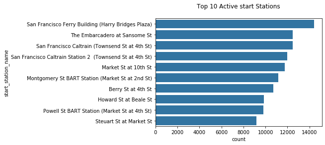

```python
# index for top 10 start stations
top10st = df_c['start_station_name'].value_counts()[:10].sort_values(ascending = False).index
df_c_top10st = df_c[df_c['start_station_name'].isin(top10st)]

# plotting
base_color = sb.color_palette()[0]
sb.countplot(data = df_c_top10st, y= 'start_station_name', color= base_color, order = top10st);
plt.title('Top 10 Active start Stations\n');
```

## End Station (investigate top 10)

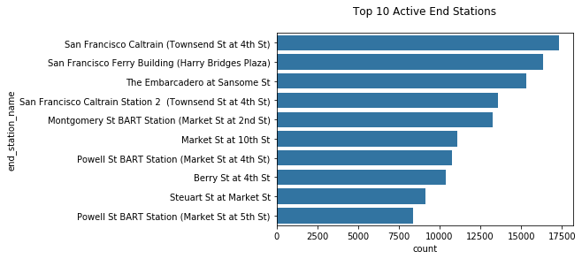

```python
# index for top 10 end stations
top10end = df_c['end_station_name'].value_counts()[:10].sort_values(ascending = False).index
df_c_top10end = df_c[df_c['end_station_name'].isin(top10end)]

# plotting
base_color = sb.color_palette()[0]
sb.countplot(data = df_c_top10end, y= 'end_station_name', color= base_color, order = top10end);
plt.title('Top 10 Active End Stations\n');
```

```python
active_st = top10st & top10end

print('Most Active stations:\n', list(active_st))
```

```
Most Active stations:
 ['San Francisco Ferry Building (Harry Bridges Plaza)', 'The Embarcadero at Sansome St', 'San Francisco Caltrain (Townsend St at 4th St)', 'San Francisco Caltrain Station 2  (Townsend St at 4th St)', 'Market St at 10th St', 'Montgomery St BART Station (Market St at 2nd St)', 'Berry St at 4th St', 'P…
```

## Duration in minutes

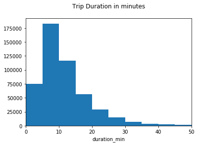

```python
bins = np.arange(0, df_c['duration_min'].max()+5 , 5)
sb.distplot(df_c['duration_min'], kde= False, hist_kws= {'alpha': 1}, bins =bins);
plt.xlim(0,50);
plt.title('Trip Duration in minutes\n');
```

> **Most trips take less than 20 minutes, and the majority of them between aboyt 5 and 15 minutes**

## User Type

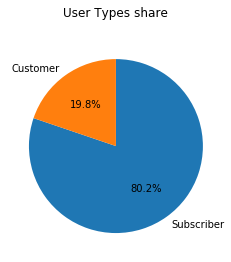

```python
user_index = df_c['user_type'].value_counts().index
plt.pie(df_c['user_type'].value_counts(),  labels = user_index,
        startangle = 90, counterclock = False, autopct='%1.1f%%');
plt.title('User Types share\n');
```

> **Subscribers (Members) are normally active(about 80%) more than Customers(Casual)(about 20%)**

## Start Month

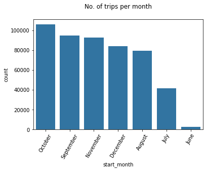

```python
order = df_c['start_month'].value_counts().index
base_color = sb.color_palette()[0]
sb.countplot(df_c['start_month'], order= order, color = base_color);
plt.xticks(rotation = 60);
plt.title('No. of trips per month\n');
```

> **June data is not complete, so it is out of comparison, but maybe University study affect in increasing of trips and in summer, No. of trips decrease**

## Weekday

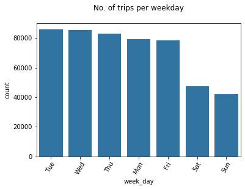

```python
order = df_c['week_day'].value_counts().index
base_color = sb.color_palette()[0]
sb.countplot(df_c['week_day'], order= order, color = base_color);
plt.xticks(rotation = 60);
plt.title('No. of trips per weekday\n');
```

> **Normally, Saturday and Sunday (holidays) have less trips**

## Period

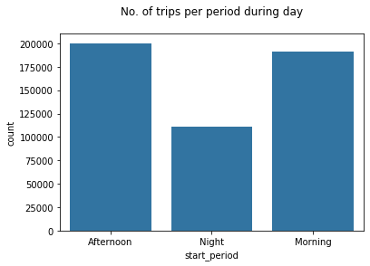

```python
sb.countplot(df_c['start_period'], color = base_color);
plt.title('No. of trips per period during day\n');
```

> **Normally, Morning and Afternoon (working hours) have trips more than Night**

## Distance

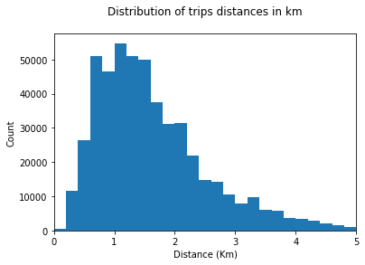

```python
bins = np.arange(0, df_c['distance_km'].max()+0.1, 0.2)
plt.hist(df_c['distance_km'], bins = bins);
plt.xlim(0,5);
plt.title('Distribution of trips distances in km\n');
plt.xlabel('Distance (Km)');
plt.ylabel('Count');
```

> **Most trips used for distances less than 3 km, and the majority of them are between about 0.5 and 2 km**

## Duration and User Type

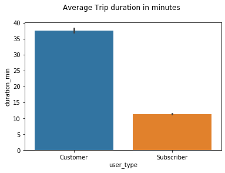

```python
sb.barplot(x="user_type",y="duration_min", data=df_c);
plt.title('Average Trip duration in minutes \n');
```

> **Although Customers are casual users, they, in average, make longer trips than Subscribers**

## User Type and Distance

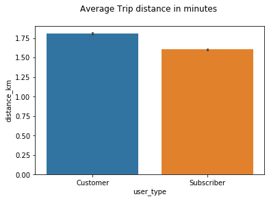

```python
sb.barplot(x="user_type",y="distance_km", data=df_c);
plt.title('Average Trip distance in minutes \n');
```

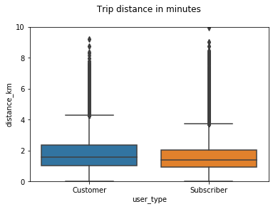

```python
sb.boxplot(x="user_type",y="distance_km", data=df_c);
plt.ylim(0,10);
plt.title(' Trip distance in minutes \n');
```

> **ِApproximately, same average and range distance for both user types**

## Duration and Month

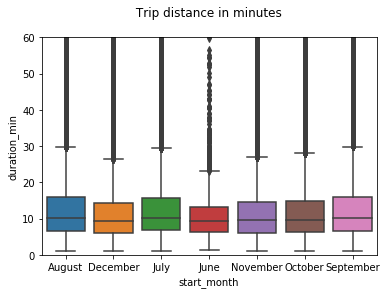

```python
sb.boxplot(x="start_month",y="duration_min", data=df_c);
plt.ylim(0,60);
plt.title(' Trip distance in minutes \n');
```

> **ِApproximately, same average and range duration for all months**

## Multivariate Exploration

> Create plots of three or more variables to investigate your data even further. Make sure that your investigations are justified, and follow from your work in the previous sections.

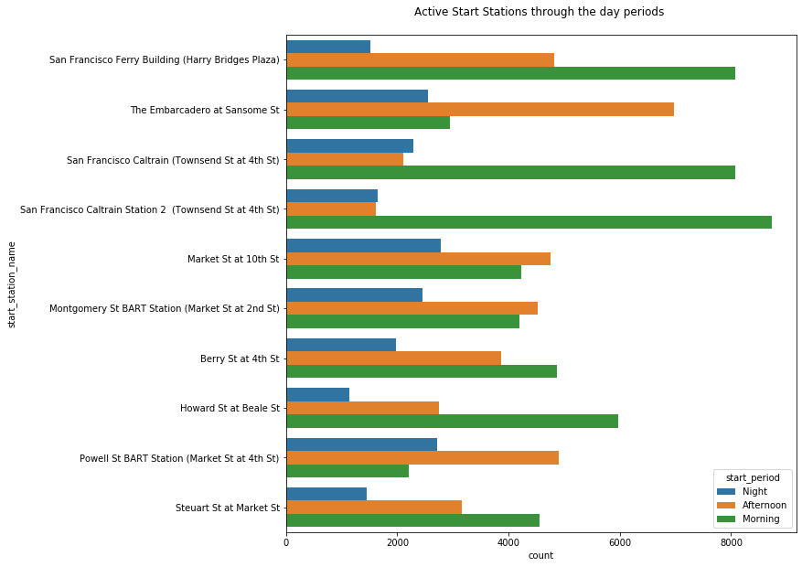

```python
# station, count, period
plt.figure(figsize = [10, 10])

sb.countplot(data = df_c_top10st, y= 'start_station_name',
             hue = 'start_period', order = top10st);
plt.title('Active Start Stations through the day periods \n');
```

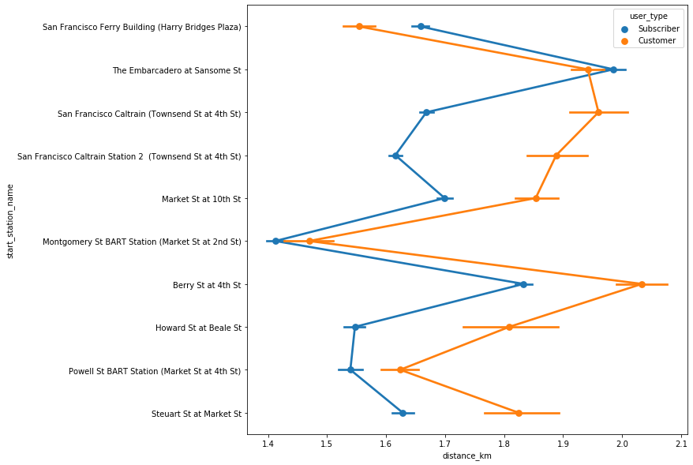

```python
# station, count, user_type
plt.figure(figsize = [10, 10])

sb.pointplot(data = df_c_top10st, y= 'start_station_name',
             x = 'distance_km',hue ='user_type', order = top10st);
```

> **Stations used for long trips:**
> - The Embarcadero at Sansome St
> - Berry St at 4th St

> **Stations used for short trips:**
> - Montgomery St BART Station (Market St at 2nd St)
> - Powell St BART Station (Market St at 4th St)
> - Howard St at Beal St

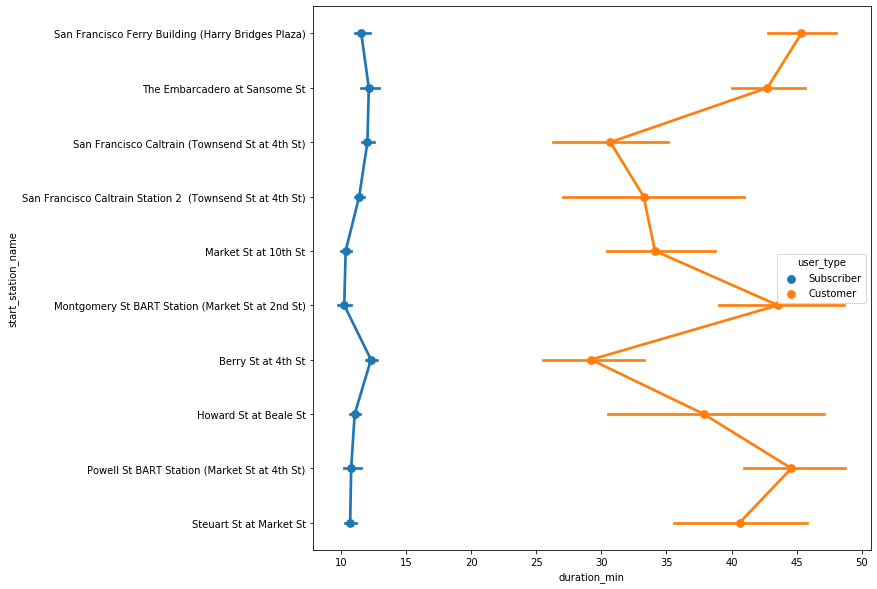

```python
plt.figure(figsize = [10, 10])
sb.pointplot(data = df_c_top10st, y= 'start_station_name',
             x = 'duration_min',hue ='user_type', order = top10st);
```

# Conclusion

- **Most Active stations:**
  - San Francisco Ferry Building (Harry Bridges Plaza)
  - The Embarcadero at Sansome St
  - San Francisco Caltrain (Townsend St at 4th St)
  - San Francisco Caltrain Station 2 (Townsend St at 4th St)
  - Market St at 10th St
  - Montgomery St BART Station (Market St at 2nd St)
  - Berry St at 4th St
  - Powell St BART Station (Market St at 4th St)
  - Steuart St at Market St']
- **Most trips take less than 20 minutes, and the majority of them between aboyt 5 and 15 minutes**
- **Subscribers (Members) are normally active(about 80%) more than Customers(Casual)(about 20%)**
- **June data is not complete, so it is out of comparison, but maybe University study affect in increasing of trips and in summer, No. of trips decrease**
- **Normally, Saturday and Sunday (holidays) have less trips**
- **Most trips used for distances less than 3 km, and the majority of them are between about 0.5 and 2 km**
- **Although Customers are casual users, they, in average, make longer trips than Subscribers**
- **Stations used for long trips:**
  - The Embarcadero at Sansome St
  - Berry St at 4th St
- **Stations used for short trips:**
  - Montgomery St BART Station (Market St at 2nd St)
  - Powell St BART Station (Market St at 4th St)
  - Howard St at Beal St